# Practical ML Assignment

Hernan Solano

21/07/2018

# Executive Summary

This is the peer assignment for the Practical Machine Learning course of the Data Science Specialization. We are going to use the Wearable Computing dataset. The objective is to use a supervised ML method to predict the “classe”" variable that correspond to one of the five positiones in which people do exercises: “A”, “B”, “C”, “D” and “E”.

## Data Slicing

I will be using the tidyverse and caret packages in order to propose a statistical model that predicts the Classe Variable. In order to validate the model we will have three datasets, a training dataset with a 5/4 cross validation strategy (model_train and model_test) and a provided testing dataset.

In order to select the predictors to be included on the model I chose to ignore the covariates with near zero variance and also those with a mean absolute correlation higer than 0.9. For these steps I used the nearZeroVar and the findCorrelation functions respectively. I applied them to the training dataset (model_train) and as a result the following variables were not included in the model:

```r
var
```

```
##   [1] "accel_arm_x"              "accel_arm_y"
##   [3] "accel_arm_z"              "accel_belt_x"
##   [5] "accel_belt_y"             "accel_belt_z"
##   [7] "accel_dumbbell_x"         "accel_dumbbell_y"
##   [9] "accel_dumbbell_z"         "accel_forearm_y"
##  [11] "amplitude_pitch_arm"      "amplitude_pitch_belt"
##  [13] "amplitude_pitch_dumbbell" "amplitude_pitch_forearm"
##  [15] "amplitude_roll_arm"       "amplitude_roll_belt"
##  [17] "amplitude_roll_dumbbell"  "amplitude_roll_forearm"
##  [19] "amplitude_yaw_arm"        "amplitude_yaw_belt"
##  [21] "amplitude_yaw_dumbbell"   "amplitude_yaw_forearm"
##  [23] "avg_pitch_arm"            "avg_pitch_belt"
##  [25] "avg_pitch_dumbbell"       "avg_pitch_forearm"
##  [27] "avg_roll_arm"             "avg_roll_belt"
##  [29] "avg_roll_dumbbell"        "avg_roll_forearm"
```

[output cut: 46 more lines]

## Model Training

I tried different models, tree methods like rpart, but the best I could think of in terms of time of computing and accuracy was the linear discriminant analysis.

### Training rpart

The rpart method gives a 66% accuracy and with the help of the following confusion matrix we can see that only A and B cases are well classified.

```r
confusionMatrix(rpart_train_prediction,as.factor(model_train$classe))
```

```
## Confusion Matrix and Statistics
##
##           Reference
## Prediction    A    B    C    D    E
##          A 4464    0    0    0    0
##          B    0 3038    0    0    0
##          C    0    0    0    0    0
##          D    0    0    0    0    0
##          E    0    0 2738 2573 2886
##
## Overall Statistics
##
##                Accuracy : 0.6617
##                  95% CI : (0.6542, 0.6691)
##     No Information Rate : 0.2843
##     P-Value [Acc > NIR] : < 2.2e-16
##
##                   Kappa : 0.5694
##  Mcnemar's Test P-Value : NA
##
## Statistics by Class:
##
##                      Class: A Class: B Class: C Class: D Class: E
## Sensitivity            1.0000   1.0000   0.0000   0.0000   1.0000
## Specificity            1.0000   1.0000   1.0000   1.0000   0.5855
## Pos Pred Value         1.0000   1.0000      NaN      NaN   0.3521
## Neg Pred Value         1.0000   1.0000   0.8256   0.8361   1.0000
## Prevalence             0.2843   0.1935   0.1744   0.1639   0.1838
## Detection Rate         0.2843   0.1935   0.0000   0.0000   0.1838
## Detection Prevalence   0.2843   0.1935   0.0000   0.0000   0.5221
## Balanced Accuracy      1.0000   1.0000   0.5000   0.5000   0.7927
```

In terms of variables and the rules of this Tree and the Variable importance list, only the X1 variable was taken into account.

```r
imp <- varImp(rpart_fit)$importance %>% mutate(var = row.names(.)) %>% arrange(desc(Overall)) %>% select(var,Overall) %>% filter(Overall > 10)
imp
```

```
##                    var   Overall
## 1                   X1 100.00000
## 2     total_accel_belt  17.39208
## 3        pitch_forearm  12.17967
## 4 raw_timestamp_part_1  11.69793
```

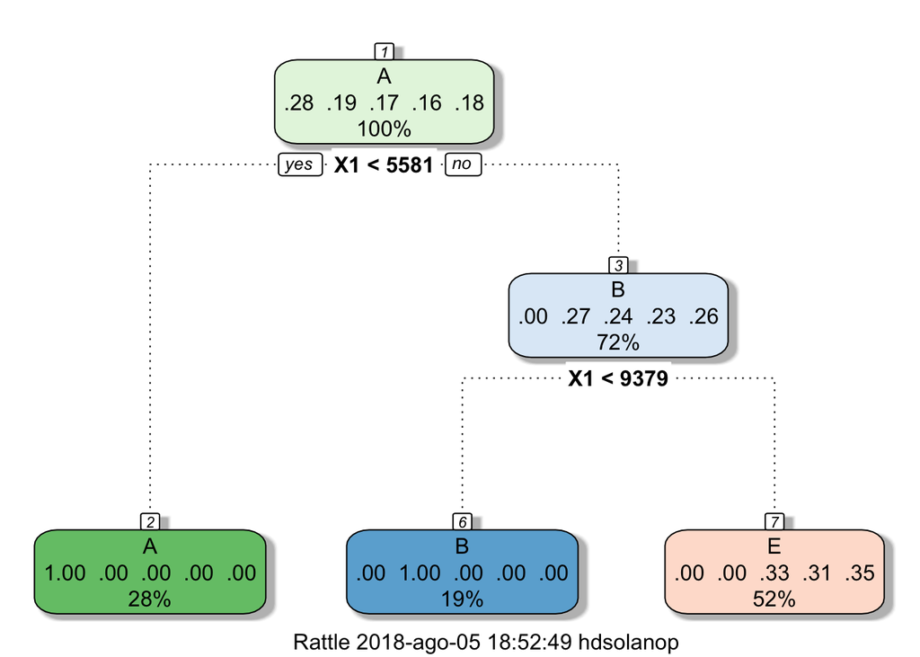

```r
fancyRpartPlot(rpart_fit$finalModel,roundint=FALSE)
```

###Training lda

Here are the results of doing the lda training:

```r
confusionMatrix(lda_train_prediction,as.factor(model_train$classe))
```

```
## Confusion Matrix and Statistics
##
##           Reference
## Prediction    A    B    C    D    E
##          A 4464    0    0    0    0
##          B    0 3038    0    0    0
##          C    0    0 2738    0    0
##          D    0    0    0 2573    0
##          E    0    0    0    0 2886
##
## Overall Statistics
##
##                Accuracy : 1
##                  95% CI : (0.9998, 1)
##     No Information Rate : 0.2843
##     P-Value [Acc > NIR] : < 2.2e-16
##
##                   Kappa : 1
##  Mcnemar's Test P-Value : NA
##
## Statistics by Class:
##
##                      Class: A Class: B Class: C Class: D Class: E
## Sensitivity            1.0000   1.0000   1.0000   1.0000   1.0000
## Specificity            1.0000   1.0000   1.0000   1.0000   1.0000
## Pos Pred Value         1.0000   1.0000   1.0000   1.0000   1.0000
## Neg Pred Value         1.0000   1.0000   1.0000   1.0000   1.0000
## Prevalence             0.2843   0.1935   0.1744   0.1639   0.1838
## Detection Rate         0.2843   0.1935   0.1744   0.1639   0.1838
## Detection Prevalence   0.2843   0.1935   0.1744   0.1639   0.1838
## Balanced Accuracy      1.0000   1.0000   1.0000   1.0000   1.0000
```

## Prediction

```r
lda_test_prediction <- predict(lda_fit,newdata = model_test)

rpart_test_prediction <- predict(rpart_fit,newdata = model_test)
```

Note: This document is licensed under the Creative Commons license (CC BY-SA).

## References

The Dataset for this assigment commes from:

Ugulino, W.; Cardador, D.; Vega, K.; Velloso, E.; Milidiu, R.; Fuks, H. Wearable Computing: Accelerometers’ Data Classification of Body Postures and Movements. Proceedings of 21st Brazilian Symposium on Artificial Intelligence. Advances in Artificial Intelligence - SBIA 2012. In: Lecture Notes in Computer Science. , pp. 52-61. Curitiba, PR: Springer Berlin / Heidelberg, 2012. ISBN 978-3-642-34458-9. DOI: 10.1007/978-3-642-34459-6_6.